# Web Experiment Analysis

Bodo Winter

7/30/2019

## Preliminaries

Load packages:

```r
library(tidyverse) # for data wrangling
library(ade4) # for mantel tests
```

Load data:

```r
web <- read_csv('../data/online_cleaned.csv')
```

Load ggplot2 theme:

```r
source('theme_timo.R')
```

## Demographics and participant N to report

How many speakers?

```r
length(unique(web$ID))
```

```
## [1] 789
```

How many men and women?

```r
table(filter(web, !duplicated(ID))$Sex)
```

```
##
##   F   M
## 596 193
```

What is the average age and age range?

```r
# Average age:

mean(filter(web, !duplicated(ID))$Age)
```

```
## [1] 32.48923
```

```r
# Age range:

range(filter(web, !duplicated(ID))$Age)
```

```
## [1] 18 84
```

How many per language?

```r
sort(table(filter(web, !duplicated(ID))$Name))
```

```
##
##   Albanian   Georgian       Thai    Amharic     Danish    Swedish
##          7         11         14         16         18         18
##       Zulu     Korean      Farsi   Romanian    Spanish    Chinese
##         18         19         20         25         26         29
##  Hungarian    Russian      Greek    Turkish   Estonian     Polish
##         32         32         36         38         42         45
##    Italian   Japanese     French Portuguese English UK     German
##         48         48         52         55         66         74
```

## Descriptive statistics

Check overall accuracy:

```r
str_c(round(mean(web$ACC), 2) * 100, '%')
```

```
## [1] "64%"
```

Check accuracy by language:

```r
lang_avgs <- web %>% group_by(Name, Family) %>%
  summarize(ACC = mean(ACC)) %>%
  arrange(desc(ACC))

# Check:

lang_avgs %>% print(n = Inf)
```

```
## # A tibble: 24 x 3
## # Groups:   Name [24]
##    Name       Family   ACC
##    <chr>      <chr>  <dbl>
##  1 German     IE     0.723
##  2 English UK IE     0.722
##  3 Danish     IE     0.715
##  4 Swedish    IE     0.708
##  5 Estonian   other  0.682
##  6 Korean     other  0.661
##  7 Hungarian  other  0.652
##  8 Romanian   IE     0.652
##  9 Russian    IE     0.651
## 10 French     IE     0.649
## 11 Greek      IE     0.643
## 12 Spanish    IE     0.641
## 13 Amharic    other  0.629
## 14 Polish     IE     0.628
## 15 Georgian   other  0.626
## 16 Italian    IE     0.623
## 17 Portuguese IE     0.622
## 18 Japanese   other  0.617
## 19 Turkish    other  0.584
## 20 Farsi      IE     0.575
## 21 Albanian   IE     0.537
## 22 Chinese    other  0.536
## 23 Zulu       other  0.534
## 24 Thai       other  0.514
```

Check accuracy by language family:

```r
family_avgs <- web %>% group_by(Genus) %>%
  summarize(ACC = mean(ACC)) %>%
  arrange(desc(ACC))

# Check:

family_avgs %>% print(n = Inf)
```

```
## # A tibble: 10 x 2
##    Genus          ACC
##    <chr>        <dbl>
##  1 Finno-Ugric  0.669
##  2 IE           0.661
##  3 Korean       0.661
##  4 Afro-Asiatic 0.629
##  5 Kartvelian   0.626
##  6 Japanese     0.617
##  7 Turkic       0.584
##  8 Sino-Tibetan 0.536
##  9 Benue-Congo  0.534
## 10 Tai-Kadai    0.514
```

Check accuracy by language area:

```r
area_avgs <- web %>% group_by(Autotyp_Area) %>%
  summarize(ACC = mean(ACC)) %>%
  arrange(desc(ACC))

# Check:

area_avgs %>% print(n = Inf)
```

```
## # A tibble: 7 x 2
##   Autotyp_Area          ACC
##   <chr>               <dbl>
## 1 Inner Asia          0.669
## 2 Europe              0.665
## 3 Greater Abyssinia   0.629
## 4 N Coast Asia        0.629
## 5 Greater Mesopotamia 0.588
## 6 S Africa            0.534
## 7 Southeast Asia      0.529
```

Check accuracy by item:

```r
item_avgs <- web %>% group_by(Meaning, category, subcategory) %>%
  summarize(ACC = mean(ACC)) %>%
  arrange(desc(ACC))

# Check:

item_avgs %>% print(n = Inf)
```

```
## # A tibble: 30 x 4
## # Groups:   Meaning, category [30]
##    Meaning category subcategory     ACC
##    <chr>   <chr>    <chr>         <dbl>
##  1 sleep   action   action        0.987
##  2 eat     action   action        0.950
##  3 child   noun     people        0.888
##  4 tiger   noun     animal        0.867
##  5 water   noun     inanimate     0.816
##  6 snake   noun     animal        0.807
##  7 hunt    action   action        0.793
##  8 pound   action   action        0.787
##  9 bad     property adjective     0.767
## 10 cut     action   action        0.743
## 11 fire    noun     inanimate     0.723
```

[output cut: 19 more lines]

Check accuracy by team:

```r
web %>% group_by(Team) %>%
  summarize(ACC = mean(ACC)) %>%
  arrange(desc(ACC)) %>%
  print(n = Inf)
```

```
## # A tibble: 11 x 2
##    Team    ACC
##    <chr> <dbl>
##  1 MS    0.801
##  2 SU    0.741
##  3 IL    0.677
##  4 NC    0.659
##  5 TM    0.635
##  6 KR    0.629
##  7 BW    0.625
##  8 GB    0.620
##  9 KD    0.613
## 10 LJ    0.554
## 11 AB    0.230
```

Check accuracy by meaning categories:

```r
web %>% group_by(category) %>%
  summarize(ACC = mean(ACC)) %>%
  arrange(desc(ACC)) %>%
  print(n = Inf)
```

```
## # A tibble: 3 x 2
##   category   ACC
##   <chr>    <dbl>
## 1 action   0.709
## 2 noun     0.675
## 3 property 0.555
```

Check accuracy by meaning subcategories:

```r
web %>% group_by(subcategory) %>%
  summarize(ACC = mean(ACC)) %>%
  arrange(desc(ACC)) %>%
  print(n = Inf)
```

```
## # A tibble: 7 x 2
##   subcategory     ACC
##   <chr>         <dbl>
## 1 animal        0.758
## 2 action        0.709
## 3 people        0.694
## 4 inanimate     0.623
## 5 adjective     0.593
## 6 quantifier    0.549
## 7 demonstrative 0.448
```

Check accuracy by gender:

```r
# By-speaker averages:

speaker_avgs <- web %>% group_by(ID, Language, Sex, Age) %>%
  summarize(ACC = mean(ACC)) %>%
  arrange(desc(ACC)) %>%
  print(n = 10)
```

```
## # A tibble: 789 x 5
## # Groups:   ID, Language, Sex [789]
##    ID         Language Sex     Age   ACC
##    <chr>      <chr>    <chr> <dbl> <dbl>
##  1 DE_2003687 DE       F        48 0.888
##  2 PL_1997874 PL       F        27 0.888
##  3 EN_2035547 EN       F        28 0.878
##  4 EN_1993336 EN       F        27 0.867
##  5 EN_2029700 EN       F        24 0.867
##  6 DE_2035314 DE       F        23 0.854
##  7 DK_2144114 DK       F        24 0.844
##  8 SE_2084957 SE       F        29 0.844
##  9 DE_2043986 DE       F        42 0.843
## 10 EN_2007249 EN       M        56 0.833
## # … with 779 more rows
```

```r
# Average:

speaker_avgs %>% group_by(Sex) %>%
  summarize(ACC = mean(ACC))
```

```
## # A tibble: 2 x 2
##   Sex     ACC
##   <chr> <dbl>
## 1 F     0.644
## 2 M     0.646
```

How any speakers above chance?

```r
sum(speaker_avgs$ACC > 1/6) / nrow(speaker_avgs)
```

```
## [1] 1
```

All speakers above chance!

Check accuracy by age:

```r
# Correlation value:

with(speaker_avgs, cor(Age, ACC, method = 'spearman'))
```

```
## [1] 0.06569903
```

No strong correlation. Check age across languages, from oldest to youngest:

```r
speaker_avgs %>% group_by(Language) %>%
  summarize(Age = mean(Age)) %>%
  arrange(desc(Age)) %>%
  print(n = Inf)
```

```
## # A tibble: 24 x 2
##    Language   Age
##    <chr>    <dbl>
##  1 HU        44.7
##  2 AL        43.9
##  3 GE        40
##  4 TH        39.8
##  5 FR        39.2
##  6 SE        38.9
##  7 EE        38.0
##  8 ES        36.0
##  9 DE        35.3
## 10 CN        34.4
## 11 EN        33.1
## 12 RU        32.3
## 13 RO        31.5
## 14 GR        30.6
## 15 FA        30.6
## 16 PT        29.5
## 17 IT        29.4
## 18 DK        28.2
## 19 KR        27.7
## 20 TR        27.2
## 21 PL        25.6
## 22 JP        25.1
## 23 ZU        24.9
## 24 AM        24.5
```

How does accuracy depend on playbacks?

```r
web %>% group_by(Rep) %>%
  summarize(ACC = mean(ACC)) %>%
  print(n = Inf)
```

```
## # A tibble: 33 x 2
##      Rep   ACC
##    <dbl> <dbl>
##  1     1 0.703
##  2     2 0.585
##  3     3 0.511
##  4     4 0.503
##  5     5 0.480
##  6     6 0.431
##  7     7 0.420
##  8     8 0.433
##  9     9 0.433
## 10    10 0.351
## 11    11 0.412
## 12    12 0.261
```

[output cut: 21 more lines]

If at all accuracy decreases.

Check accuracy by L2 proficiency:

```r
web %>% group_by(EnglishL2) %>%
  summarize(ACC = mean(ACC))
```

```
## # A tibble: 3 x 2
##   EnglishL2   ACC
##   <lgl>     <dbl>
## 1 FALSE     0.686
## 2 TRUE      0.646
## 3 NA        0.613
```

## Marcus’s descriptive statistics: how many meanings per language above chance?

A simple way to summarize this data is to check how many meanings are guessed above chance per language.

First, let’s get a vector with the language names which we’ll use for looping:

```r
languages <- unique(web$Language)

# Check:

languages
```

```
##  [1] "AL" "AM" "CN" "DE" "DK" "EE" "EN" "ES" "FA" "FR" "GE" "GR" "HU" "IT"
## [15] "JP" "KR" "PL" "PT" "RO" "RU" "SE" "TH" "TR" "ZU"
```

Put this into a tibble:

```r
meanings_per_language <- tibble(Language = languages)
meanings_per_language$N_over_chance <- NA

# Check:

meanings_per_language
```

```
## # A tibble: 24 x 2
##    Language N_over_chance
##    <chr>    <lgl>
##  1 AL       NA
##  2 AM       NA
##  3 CN       NA
##  4 DE       NA
##  5 DK       NA
##  6 EE       NA
##  7 EN       NA
##  8 ES       NA
##  9 FA       NA
## 10 FR       NA
## # … with 14 more rows
```

```r
for (i in seq_along(languages)) {
  this_lang <- languages[i]
  these_avgs <- filter(web, Language == this_lang) %>%
    group_by(Meaning) %>%
    summarize(ACC = mean(ACC))
  meanings_per_language[i, ]$N_over_chance <- sum(these_avgs$ACC > 1/6)
}
```

Check the results:

```r
meanings_per_language %>% print(n = Inf)
```

```
## # A tibble: 24 x 2
##    Language N_over_chance
##    <chr>            <int>
##  1 AL                  28
##  2 AM                  30
##  3 CN                  30
##  4 DE                  30
##  5 DK                  30
##  6 EE                  30
##  7 EN                  30
##  8 ES                  29
##  9 FA                  29
## 10 FR                  30
## 11 GE                  29
## 12 GR                  30
## 13 HU                  30
## 14 IT                  30
## 15 JP                  30
## 16 KR                  30
## 17 PL                  30
## 18 PT                  29
## 19 RO                  30
## 20 RU                  30
## 21 SE                  30
## 22 TH                  29
## 23 TR                  30
## 24 ZU                  30
```

The easiest thing is to compute how many had N meanings correct:

```r
meanings_per_language %>% count(N_over_chance) %>%
  mutate(proportion = n / nrow(meanings_per_language))
```

```
## # A tibble: 3 x 3
##   N_over_chance     n proportion
##           <int> <int>      <dbl>
## 1            28     1     0.0417
## 2            29     5     0.208
## 3            30    18     0.75
```

## Publication-ready plots:

Accuracy across languages:

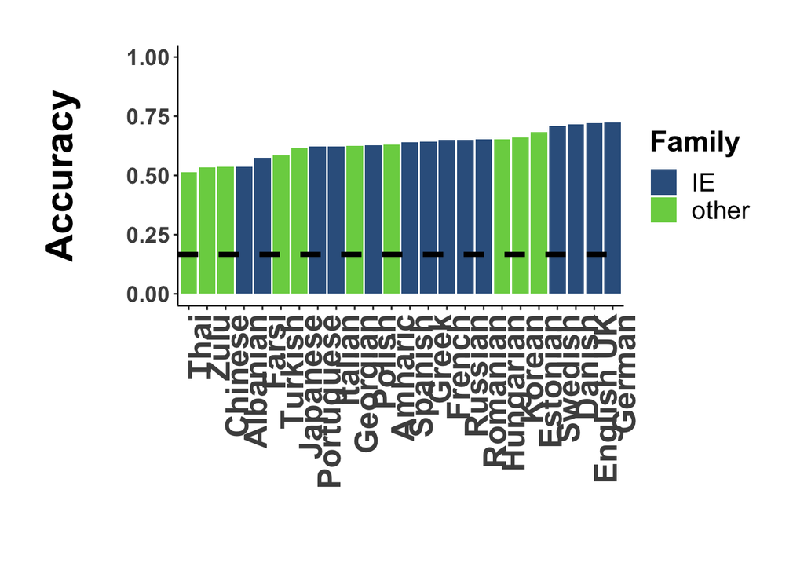

```r
lang_avgs %>%
  ggplot(aes(x = reorder(Name, ACC),
             y = ACC,
             fill = Family)) +
  geom_col() +
  geom_hline(yintercept = 1 / 6, linetype = 2, size = 1.5) +
  labs(x = '', y = 'Accuracy\n') +
  scale_fill_viridis_d(option = 'D', begin = 0.3, end = 0.8) +
  theme_timo +
  coord_cartesian(ylim = c(0, 1.0)) +
  theme(axis.text.x = element_text(angle = 90, hjust = 1, face = 'bold', size = 20),
        axis.text.y = element_text(face = 'bold', size = 14),
        axis.title = element_text(face = 'bold', size = 24))
```

```r
ggsave('../figures/web_languages.png', width = 14, height = 8)
```

Accuracy across items:

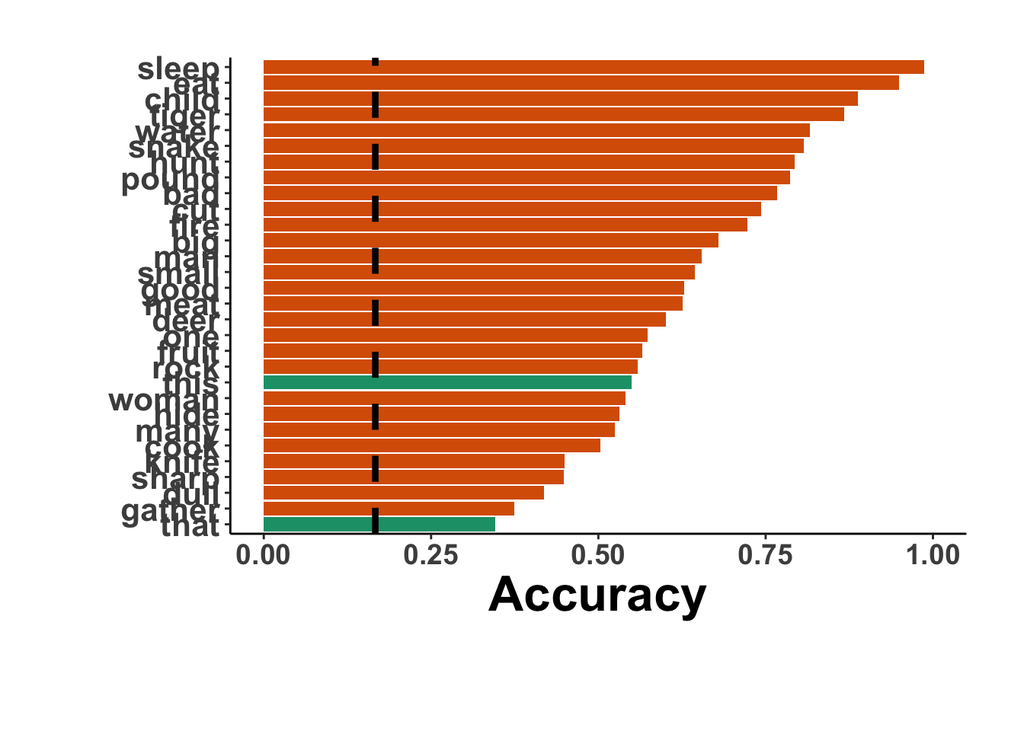

```r
item_avgs %>%
  mutate(subcategory = ifelse(subcategory == 'demonstrative', subcategory, 'other'),
         subcategory = factor(subcategory, levels = c('demonstrative', 'other'))) %>%
  rename(`Semantic Category` = subcategory) %>%
  ggplot(aes(x = reorder(Meaning, ACC),
             # y = ACC)) +
             y = ACC,
             fill = `Semantic Category`)) +
  # geom_col(fill = '#d75c07') +
  geom_col() +
  geom_hline(yintercept = 1 / 6, linetype = 2, size = 1.5) +
  labs(x = '', y = 'Accuracy\n') +
  scale_fill_brewer(palette = 'Dark2') +
  theme_timo +
  ylim(0, 1.0) +
  theme(axis.text.x = element_text(face = 'bold', size = 14),
        axis.text.y = element_text(face = 'bold', size = 16),
        axis.title = element_text(face = 'bold', size = 24),
        legend.position = 'none') +
  coord_flip()
```

```r
ggsave('../figures/web_items.png', width = 12, height = 12)
```

Accuracy across semantic categories:

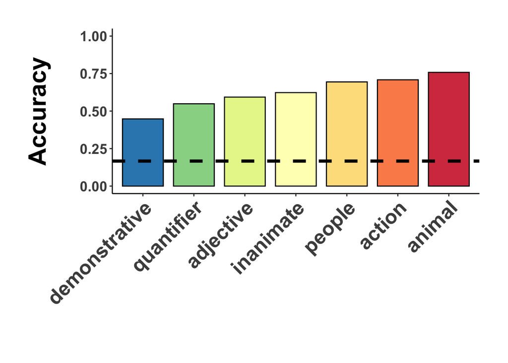

```r
web %>% group_by(subcategory) %>%
  summarize(ACC = mean(ACC)) %>%
  rename(`Semantic Category` = subcategory) %>%
  ggplot(aes(x = reorder(`Semantic Category`, ACC),
             y = ACC,
             fill = reorder(`Semantic Category`, ACC))) +
  geom_col(col = 'black', width = 0.8) +
  geom_hline(yintercept = 1 / 6, linetype = 2, size = 1.5) +
  labs(x = '', y = 'Accuracy\n') +
  scale_fill_brewer(palette = 'Spectral', direction = -1) +
  theme_timo +
  coord_cartesian(ylim = c(0, 1.0)) +
  theme(axis.text.x = element_text(angle = 45, hjust = 1, face = 'bold', size = 20),
        axis.text.y = element_text(face = 'bold', size = 14, vjus = 0.5),
        axis.title = element_text(face = 'bold', size = 24),
        legend.position = 'none')
```

```r
ggsave('../figures/web_semantics.png', width = 10, height = 8)
```

## Confusion matrices:

Check confusion, first for English:

```r
EN <- filter(web, Language == 'EN')
EN_tab <- table(EN$Meaning, EN$Choice)
EN_tab
```

```
##
##          bad big child clapping cook cut deer dull eat fire fruit gather
##   bad    120   3     0        0    0   0    1    2   0    0     0      0
##   big     32 166     1        0    1   0    2    3   1    1     0      3
##   child    0   0   184        0    0   1    0    3   0    0     0      0
##   cook     0   1     0        1  118   5    2    2  11    8     6      0
##   cut      1   0     2        0    2 147    4    1   0    4     0      3
##   deer     6   1     3        0    3   0  141    4   0    0     0      4
##   dull     5   4     1        0    3   0    4  149   3    1     0      2
##   eat      0   0     0        0    0   0    0    0 189    0     1      1
##   fire     1   1     0        0    8   3    2    2   0  159     0      1
##   fruit    2   0     1        0    8   2    3    1  21    0   131      1
##   gather   8   0     9        1    2   0    9    6   1    2     4     91
##   good     0   4     2        1    1   0    3    3   1    2     0      2
##   hide     7   2     1        0    1   5    2    1   1    6     0      0
##   hunt     2   2     0        0    0   3    0    0   0    0     0      0
##   knife    0   1     0        0    0  18    2    0   0    7     0      2
##   man     12  10     1        0    1   3    1    1   2    2     0      2
##   many     1   0     4        1    1   3    4    2   0    1     0     11
##   meat     1   0     1        0    3   0    0    1  24    0     6      2
##   one      3   0     0        2    2   6    0    2   3    1     1      1
##   pound    1   4     1        1    0   4    1    3   0    1     0      1
##   rock     1   1     1        4    2   8    2    7   0    0     1      1
##   sharp    2   1     4        0    3  14    5    0   1    8     0      0
##   sleep    0   0     0        0    0   1    0    0   0    0     0      0
##   small    1   0     7        0    1   1    1    2   2    0     0      2
##   snake    0   1     0        0    8   0    1    0   0    3     0      0
##   that     7  14     1        1    1   3    6   12   2    0     3      1
##   this     2   0     6        0    0   0    2    9   2    0     1      4
##   tiger    1   1     0        0    0   1    0    3   0    0     0      0
##   water    0   0     0        2    1   0    1    2   4    0     0      3
##   woman    3   5     8        0    0   0    5    4   0    2     1      1
##
##          good hide hunt knife man many meat one pound rock sharp sleep
##   bad       0    0    0     0   2    1    0   0     0    0     0     1
##   big       9    0    1     0   7    7    4   3     0    1     0     2
##   child     0    1    0     3   0    0    1   0     0    0     0     0
##   cook      0    1    2     2   1    1    1   1     0    0     2     7
##   cut       0    1    1     6   2    2    1   0     1    1     6     5
##   deer      1    3    3     2   6    2    0   1     0    2     4     2
```

[output cut: 41 more lines]

```
##   man        0     1    6    0     4     2     0
##   many       6     2    0    0     1     6     3
##   meat       0     0    0    0     7     1     0
##   one       10     0    8   10     0     3     1
##   pound      0     0    0    4     0     0     0
##   rock       0     0    4    6     0     9     0
##   sharp      5     5    1    5     2     4     3
##   sleep      0     0    0    0     0     0     0
##   small    142     0    5    8     0     3     2
##   snake      0   172    0    0     0     3     0
##   that       1     0   96    5     1     1     7
##   this       4     1   11  120     1     2     1
##   tiger      0     0    1    0   182     0     0
##   water      2     0    2    0     1   169     0
##   woman      4     0    2    4     1     2   132
```

We can re-use the “languages” vector from above for this.

```r
M <- rep(NA, length(languages) * length(languages))
M <- matrix(M, nrow = length(languages))

# Append row and column names:

rownames(M) <- languages
colnames(M) <- languages

# Check:

M
```

```
##    AL AM CN DE DK EE EN ES FA FR GE GR HU IT JP KR PL PT RO RU SE TH TR ZU
## AL NA NA NA NA NA NA NA NA NA NA NA NA NA NA NA NA NA NA NA NA NA NA NA NA
## AM NA NA NA NA NA NA NA NA NA NA NA NA NA NA NA NA NA NA NA NA NA NA NA NA
## CN NA NA NA NA NA NA NA NA NA NA NA NA NA NA NA NA NA NA NA NA NA NA NA NA
## DE NA NA NA NA NA NA NA NA NA NA NA NA NA NA NA NA NA NA NA NA NA NA NA NA
## DK NA NA NA NA NA NA NA NA NA NA NA NA NA NA NA NA NA NA NA NA NA NA NA NA
## EE NA NA NA NA NA NA NA NA NA NA NA NA NA NA NA NA NA NA NA NA NA NA NA NA
## EN NA NA NA NA NA NA NA NA NA NA NA NA NA NA NA NA NA NA NA NA NA NA NA NA
## ES NA NA NA NA NA NA NA NA NA NA NA NA NA NA NA NA NA NA NA NA NA NA NA NA
## FA NA NA NA NA NA NA NA NA NA NA NA NA NA NA NA NA NA NA NA NA NA NA NA NA
## FR NA NA NA NA NA NA NA NA NA NA NA NA NA NA NA NA NA NA NA NA NA NA NA NA
## GE NA NA NA NA NA NA NA NA NA NA NA NA NA NA NA NA NA NA NA NA NA NA NA NA
## GR NA NA NA NA NA NA NA NA NA NA NA NA NA NA NA NA NA NA NA NA NA NA NA NA
## HU NA NA NA NA NA NA NA NA NA NA NA NA NA NA NA NA NA NA NA NA NA NA NA NA
## IT NA NA NA NA NA NA NA NA NA NA NA NA NA NA NA NA NA NA NA NA NA NA NA NA
## JP NA NA NA NA NA NA NA NA NA NA NA NA NA NA NA NA NA NA NA NA NA NA NA NA
## KR NA NA NA NA NA NA NA NA NA NA NA NA NA NA NA NA NA NA NA NA NA NA NA NA
## PL NA NA NA NA NA NA NA NA NA NA NA NA NA NA NA NA NA NA NA NA NA NA NA NA
## PT NA NA NA NA NA NA NA NA NA NA NA NA NA NA NA NA NA NA NA NA NA NA NA NA
## RO NA NA NA NA NA NA NA NA NA NA NA NA NA NA NA NA NA NA NA NA NA NA NA NA
## RU NA NA NA NA NA NA NA NA NA NA NA NA NA NA NA NA NA NA NA NA NA NA NA NA
## SE NA NA NA NA NA NA NA NA NA NA NA NA NA NA NA NA NA NA NA NA NA NA NA NA
## TH NA NA NA NA NA NA NA NA NA NA NA NA NA NA NA NA NA NA NA NA NA NA NA NA
## TR NA NA NA NA NA NA NA NA NA NA NA NA NA NA NA NA NA NA NA NA NA NA NA NA
## ZU NA NA NA NA NA NA NA NA NA NA NA NA NA NA NA NA NA NA NA NA NA NA NA NA
```

Create two copies of this matrix, one for the correlation coefficients, another one for the p-values:

```r
r_vals <- M
p_vals <- M
```

For this it’s good to have everything as factor so that all matrices are the same (since they all work with the same factors: not all meanings were chosen in all languages).

And for this it makes sense to get rid of the choices that were “clapping”. These are incorrect in the main analysis below, but they cause problems here since “clapping” isn’t attested in the meanings at this stage in the analysis (since clapping sounds have been excluded) and thus leads to non-square matrices.

```r
# Get rid of clapping:

web2 <- filter(web,
               Choice != 'clapping')

# Factor code:

web2 <- mutate(web2,
               Meaning = factor(Meaning),
               Choice = factor(Choice))
```

Loop through languages and create distance matrices:

```r
for (i in seq_along(languages)) {
  # Cross-tabulation:

  this_tab <- with(filter(web2, Language == languages[i]), table(Meaning, Choice))

  # Get rid of the clapping from the choices, otherwise we have non-square matrices (since clapping isn't in the meanings):

  if (any(colnames(this_tab) == 'clapping')) {
  this_tab <- this_tab[, -which(colnames(this_tab) == 'clapping')]
  }

  # Transform into distance matrix object (needed for Mantel test):

  this_tab <- as.dist(this_tab)

  # Save this in an object with the name pattern "EN_tab" etc.:

  assign(str_c(languages[i], '_tab'), this_tab)
}
```

Loop through languages and put this information into the corresponding matrices:

```r
for (i in seq_along(languages)) {
  lang1 <- languages[i]
  for (j in seq_along(languages)) {
    lang2 <- languages[j]
    if (lang1 != lang2) {
      # Retrieve previously stored distance matrices:

      tab1 <- get(str_c(languages[i], '_tab'))
      tab2 <- get(str_c(languages[j], '_tab'))

      # Perform correlation:

      this_mantel <- mantel.rtest(tab1, tab2, nrepet = 999)

      # Store correlation value and p-value:

      r_vals[i, j] <- this_mantel$obs
      p_vals[i, j] <- this_mantel$pvalue

    }
  }
}
```

Check results:

```r
## Correlation values:

round(r_vals, 2)
```

```
##      AL   AM   CN   DE   DK   EE   EN   ES   FA   FR   GE   GR   HU   IT
## AL   NA 0.30 0.27 0.38 0.29 0.35 0.39 0.34 0.34 0.34 0.25 0.42 0.38 0.41
## AM 0.30   NA 0.48 0.57 0.57 0.54 0.48 0.46 0.44 0.57 0.37 0.45 0.56 0.54
## CN 0.27 0.48   NA 0.65 0.50 0.57 0.50 0.46 0.46 0.63 0.40 0.52 0.59 0.55
## DE 0.38 0.57 0.65   NA 0.72 0.76 0.72 0.58 0.56 0.75 0.43 0.58 0.73 0.68
## DK 0.29 0.57 0.50 0.72   NA 0.66 0.59 0.58 0.48 0.68 0.45 0.50 0.71 0.65
## EE 0.35 0.54 0.57 0.76 0.66   NA 0.66 0.57 0.49 0.73 0.50 0.54 0.69 0.61
## EN 0.39 0.48 0.50 0.72 0.59 0.66   NA 0.68 0.64 0.63 0.41 0.77 0.64 0.75
## ES 0.34 0.46 0.46 0.58 0.58 0.57 0.68   NA 0.54 0.61 0.45 0.68 0.61 0.72
## FA 0.34 0.44 0.46 0.56 0.48 0.49 0.64 0.54   NA 0.56 0.34 0.64 0.55 0.62
## FR 0.34 0.57 0.63 0.75 0.68 0.73 0.63 0.61 0.56   NA 0.48 0.57 0.70 0.72
## GE 0.25 0.37 0.40 0.43 0.45 0.50 0.41 0.45 0.34 0.48   NA 0.43 0.52 0.41
## GR 0.42 0.45 0.52 0.58 0.50 0.54 0.77 0.68 0.64 0.57 0.43   NA 0.55 0.73
## HU 0.38 0.56 0.59 0.73 0.71 0.69 0.64 0.61 0.55 0.70 0.52 0.55   NA 0.69
## IT 0.41 0.54 0.55 0.68 0.65 0.61 0.75 0.72 0.62 0.72 0.41 0.73 0.69   NA
## JP 0.32 0.58 0.58 0.68 0.59 0.68 0.66 0.56 0.56 0.65 0.50 0.59 0.65 0.59
## KR 0.32 0.56 0.56 0.62 0.58 0.54 0.58 0.53 0.50 0.58 0.45 0.52 0.61 0.58
## PL 0.35 0.45 0.52 0.70 0.58 0.65 0.71 0.64 0.57 0.59 0.42 0.66 0.63 0.69
## PT 0.36 0.57 0.62 0.74 0.72 0.69 0.73 0.67 0.57 0.76 0.50 0.65 0.71 0.73
## RO 0.28 0.44 0.55 0.61 0.51 0.58 0.54 0.55 0.45 0.58 0.45 0.52 0.58 0.51
## RU 0.34 0.48 0.46 0.66 0.54 0.58 0.64 0.51 0.49 0.55 0.40 0.54 0.58 0.58
## SE 0.33 0.47 0.54 0.68 0.60 0.62 0.70 0.66 0.55 0.62 0.43 0.69 0.61 0.65
## TH 0.33 0.33 0.40 0.47 0.46 0.47 0.44 0.37 0.39 0.49 0.35 0.31 0.42 0.42
## TR 0.30 0.55 0.57 0.68 0.65 0.69 0.57 0.54 0.50 0.68 0.46 0.53 0.63 0.61
## ZU 0.35 0.42 0.51 0.65 0.59 0.59 0.57 0.54 0.50 0.61 0.43 0.52 0.62 0.64
##      JP   KR   PL   PT   RO   RU   SE   TH   TR   ZU
## AL 0.32 0.32 0.35 0.36 0.28 0.34 0.33 0.33 0.30 0.35
## AM 0.58 0.56 0.45 0.57 0.44 0.48 0.47 0.33 0.55 0.42
## CN 0.58 0.56 0.52 0.62 0.55 0.46 0.54 0.40 0.57 0.51
## DE 0.68 0.62 0.70 0.74 0.61 0.66 0.68 0.47 0.68 0.65
## DK 0.59 0.58 0.58 0.72 0.51 0.54 0.60 0.46 0.65 0.59
## EE 0.68 0.54 0.65 0.69 0.58 0.58 0.62 0.47 0.69 0.59
## EN 0.66 0.58 0.71 0.73 0.54 0.64 0.70 0.44 0.57 0.57
## ES 0.56 0.53 0.64 0.67 0.55 0.51 0.66 0.37 0.54 0.54
## FA 0.56 0.50 0.57 0.57 0.45 0.49 0.55 0.39 0.50 0.50
## FR 0.65 0.58 0.59 0.76 0.58 0.55 0.62 0.49 0.68 0.61
## GE 0.50 0.45 0.42 0.50 0.45 0.40 0.43 0.35 0.46 0.43
## GR 0.59 0.52 0.66 0.65 0.52 0.54 0.69 0.31 0.53 0.52
## HU 0.65 0.61 0.63 0.71 0.58 0.58 0.61 0.42 0.63 0.62
## IT 0.59 0.58 0.69 0.73 0.51 0.58 0.65 0.42 0.61 0.64
## JP   NA 0.60 0.61 0.67 0.59 0.62 0.57 0.46 0.64 0.55
## KR 0.60   NA 0.46 0.64 0.57 0.46 0.53 0.41 0.53 0.59
## PL 0.61 0.46   NA 0.62 0.52 0.63 0.60 0.39 0.60 0.56
## PT 0.67 0.64 0.62   NA 0.59 0.59 0.68 0.50 0.67 0.64
## RO 0.59 0.57 0.52 0.59   NA 0.50 0.47 0.31 0.54 0.49
## RU 0.62 0.46 0.63 0.59 0.50   NA 0.49 0.41 0.50 0.50
## SE 0.57 0.53 0.60 0.68 0.47 0.49   NA 0.44 0.54 0.55
## TH 0.46 0.41 0.39 0.50 0.31 0.41 0.44   NA 0.49 0.49
## TR 0.64 0.53 0.60 0.67 0.54 0.50 0.54 0.49   NA 0.57
## ZU 0.55 0.59 0.56 0.64 0.49 0.50 0.55 0.49 0.57   NA
```

What’s the minimum and maximum correlation value?

```r
range(r_vals, na.rm = TRUE)
```

```
## [1] 0.2529738 0.7658758
```

What’s the mean correlation?

```r
mean(r_vals, na.rm = TRUE)
```

```
## [1] 0.5456451
```

What are the p-values?:

```r
p_vals
```

```
##       AL    AM    CN    DE    DK    EE    EN    ES    FA    FR    GE    GR
## AL    NA 0.001 0.001 0.001 0.001 0.001 0.001 0.001 0.001 0.001 0.001 0.001
## AM 0.001    NA 0.001 0.001 0.001 0.001 0.001 0.001 0.001 0.001 0.001 0.001
## CN 0.001 0.001    NA 0.001 0.001 0.001 0.001 0.001 0.001 0.001 0.001 0.001
## DE 0.001 0.001 0.001    NA 0.001 0.001 0.001 0.001 0.001 0.001 0.001 0.001
## DK 0.001 0.001 0.001 0.001    NA 0.001 0.001 0.001 0.001 0.001 0.001 0.001
## EE 0.001 0.001 0.001 0.001 0.001    NA 0.001 0.001 0.001 0.001 0.001 0.001
## EN 0.001 0.001 0.001 0.001 0.001 0.001    NA 0.001 0.001 0.001 0.001 0.001
## ES 0.001 0.001 0.001 0.001 0.001 0.001 0.001    NA 0.001 0.001 0.001 0.001
## FA 0.001 0.001 0.001 0.001 0.001 0.001 0.001 0.001    NA 0.001 0.001 0.001
## FR 0.001 0.001 0.001 0.001 0.001 0.001 0.001 0.001 0.001    NA 0.001 0.001
## GE 0.001 0.001 0.001 0.001 0.001 0.001 0.001 0.001 0.001 0.001    NA 0.001
## GR 0.001 0.001 0.001 0.001 0.001 0.001 0.001 0.001 0.001 0.001 0.001    NA
## HU 0.001 0.001 0.001 0.001 0.001 0.001 0.001 0.001 0.001 0.001 0.001 0.001
## IT 0.001 0.001 0.001 0.001 0.001 0.001 0.001 0.001 0.001 0.001 0.001 0.001
## JP 0.001 0.001 0.001 0.001 0.001 0.001 0.001 0.001 0.001 0.001 0.001 0.001
## KR 0.001 0.001 0.001 0.001 0.001 0.001 0.001 0.001 0.001 0.001 0.001 0.001
## PL 0.001 0.001 0.001 0.001 0.001 0.001 0.001 0.001 0.001 0.001 0.001 0.001
## PT 0.001 0.001 0.001 0.001 0.001 0.001 0.001 0.001 0.001 0.001 0.001 0.001
## RO 0.001 0.001 0.001 0.001 0.001 0.001 0.001 0.001 0.001 0.001 0.001 0.001
## RU 0.001 0.001 0.001 0.001 0.001 0.001 0.001 0.001 0.001 0.001 0.001 0.001
## SE 0.001 0.001 0.001 0.001 0.001 0.001 0.001 0.001 0.001 0.001 0.001 0.001
## TH 0.001 0.001 0.001 0.001 0.001 0.001 0.001 0.001 0.001 0.001 0.001 0.001
## TR 0.001 0.001 0.001 0.001 0.001 0.001 0.001 0.001 0.001 0.001 0.001 0.001
## ZU 0.001 0.001 0.001 0.001 0.001 0.001 0.001 0.001 0.001 0.001 0.001 0.001
##       HU    IT    JP    KR    PL    PT    RO    RU    SE    TH    TR    ZU
## AL 0.001 0.001 0.001 0.001 0.001 0.001 0.001 0.001 0.001 0.001 0.001 0.001
## AM 0.001 0.001 0.001 0.001 0.001 0.001 0.001 0.001 0.001 0.001 0.001 0.001
## CN 0.001 0.001 0.001 0.001 0.001 0.001 0.001 0.001 0.001 0.001 0.001 0.001
## DE 0.001 0.001 0.001 0.001 0.001 0.001 0.001 0.001 0.001 0.001 0.001 0.001
## DK 0.001 0.001 0.001 0.001 0.001 0.001 0.001 0.001 0.001 0.001 0.001 0.001
## EE 0.001 0.001 0.001 0.001 0.001 0.001 0.001 0.001 0.001 0.001 0.001 0.001
## EN 0.001 0.001 0.001 0.001 0.001 0.001 0.001 0.001 0.001 0.001 0.001 0.001
## ES 0.001 0.001 0.001 0.001 0.001 0.001 0.001 0.001 0.001 0.001 0.001 0.001
## FA 0.001 0.001 0.001 0.001 0.001 0.001 0.001 0.001 0.001 0.001 0.001 0.001
## FR 0.001 0.001 0.001 0.001 0.001 0.001 0.001 0.001 0.001 0.001 0.001 0.001
## GE 0.001 0.001 0.001 0.001 0.001 0.001 0.001 0.001 0.001 0.001 0.001 0.001
## GR 0.001 0.001 0.001 0.001 0.001 0.001 0.001 0.001 0.001 0.001 0.001 0.001
## HU    NA 0.001 0.001 0.001 0.001 0.001 0.001 0.001 0.001 0.001 0.001 0.001
## IT 0.001    NA 0.001 0.001 0.001 0.001 0.001 0.001 0.001 0.001 0.001 0.001
## JP 0.001 0.001    NA 0.001 0.001 0.001 0.001 0.001 0.001 0.001 0.001 0.001
## KR 0.001 0.001 0.001    NA 0.001 0.001 0.001 0.001 0.001 0.001 0.001 0.001
## PL 0.001 0.001 0.001 0.001    NA 0.001 0.001 0.001 0.001 0.001 0.001 0.001
## PT 0.001 0.001 0.001 0.001 0.001    NA 0.001 0.001 0.001 0.001 0.001 0.001
## RO 0.001 0.001 0.001 0.001 0.001 0.001    NA 0.001 0.001 0.001 0.001 0.001
## RU 0.001 0.001 0.001 0.001 0.001 0.001 0.001    NA 0.001 0.001 0.001 0.001
## SE 0.001 0.001 0.001 0.001 0.001 0.001 0.001 0.001    NA 0.001 0.001 0.001
## TH 0.001 0.001 0.001 0.001 0.001 0.001 0.001 0.001 0.001    NA 0.001 0.001
## TR 0.001 0.001 0.001 0.001 0.001 0.001 0.001 0.001 0.001 0.001    NA 0.001
## ZU 0.001 0.001 0.001 0.001 0.001 0.001 0.001 0.001 0.001 0.001 0.001    NA
```

For how many comparisons would we have to correct?

```r
length(languages) * (length(languages) - 1) / 2
```

```
## [1] 276
```

```r
# Vector of adjusted p-values from upper triangle of the matrix:

adjusted_p <- p.adjust(p_vals[upper.tri(p_vals)], method = 'bonferroni', n = 300)

# How many significant?

sum(adjusted_p < 0.05)
```

```
## [1] 0
```

None after correction.

The better approach would be to calculate how many we expect to be significant based on chance alone for an alpha level of 0.05.

```r
300 * 0.05
```

```
## [1] 15
```

Only 15. And how many are significant? (before correction)

```r
sum(p_vals[upper.tri(p_vals)] < 0.05)
```

```
## [1] 276
```

This completes this analysis.